# Reproduceable Research - Assignment 2

RHays

10/17/2020

```r
library(tidyverse)
```

```r
library(readr)
library(ggplot2)
activity_data <- read_csv("activity.csv")
```

## 1. Total number of steps taken per day

```r
steps_per_day <- activity_data %>%
        filter(!is.na(steps)) %>%
           group_by(date) %>%
                summarize(steps = sum(steps)) %>%
  print
```

```
## # A tibble: 53 x 2
##    date       steps
##    <date>     <dbl>
##  1 2012-10-02   126
##  2 2012-10-03 11352
##  3 2012-10-04 12116
##  4 2012-10-05 13294
##  5 2012-10-06 15420
##  6 2012-10-07 11015
##  7 2012-10-09 12811
##  8 2012-10-10  9900
##  9 2012-10-11 10304
## 10 2012-10-12 17382
## # ... with 43 more rows
```

## 2. Histogram of the total number of steps taken each day

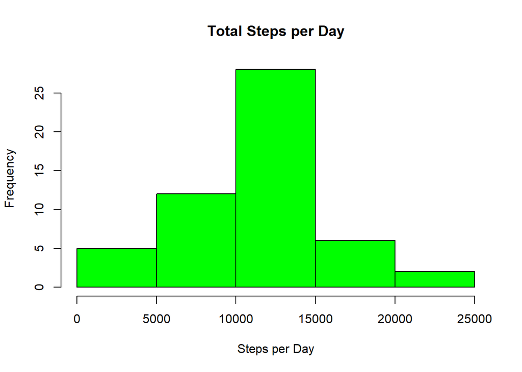

```r
hist(steps_per_day$steps, xlab = "Steps per Day", main = "Total Steps per Day", col = "green")
```

```r
mean_steps <- mean(steps_per_day$steps) %>% print()
```

```
## [1] 10766.19
```

```r
median_steps <- median(steps_per_day$steps) %>% print()
```

```
## [1] 10765
```

Mean Steps per day 10766.19 Median Steps per day 10765

## 3. What is the average daily activity pattern?

```r
interval_steps <- activity_data %>%
  filter(!is.na(steps)) %>%
  group_by(interval) %>%
  summarize(steps = mean(steps))
```

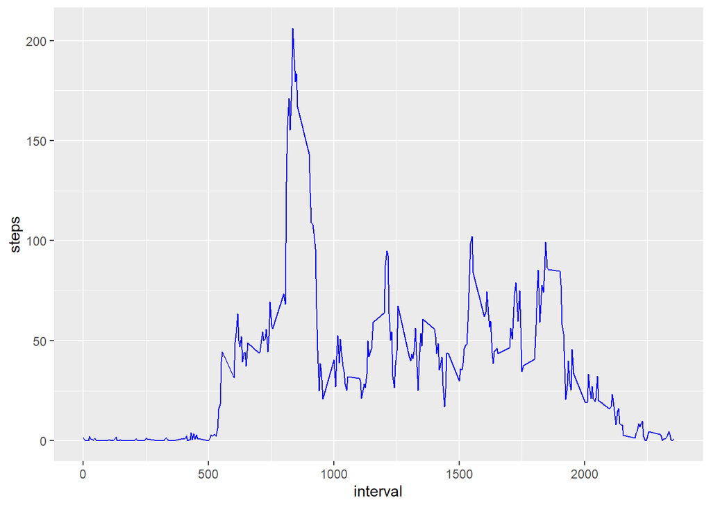

```r
ggplot(interval_steps, aes(x=interval, y=steps)) +
  geom_line(color = "blue")
```

Which 5-minute interval, on average across all the days in the dataset, contains the maximum number of steps?

Interval 835 has the the most steps at 206.17

```r
interval_steps[which.max(interval_steps$steps),]
```

```
## # A tibble: 1 x 2
##   interval steps
##      <dbl> <dbl>
## 1      835  206.
```

```r
activity_data_na_populated <- activity_data
     nas <- sum(is.na(activity_data_na_populated$steps)) %>% print()
```

```
## [1] 2304
```

```r
          avg_interval <- tapply(activity_data_na_populated$steps, activity_data_na_populated$interval, mean,                 na.rm=TRUE, simplify=TRUE)

activity_data_na_populated$steps[nas] <- avg_interval[as.character(activity_data_na_populated$interval[nas])]
View(activity_data_na_populated)
```

# Caluclate the total number of steps taken each day in the new data set

```r
no_na_steps_per_day <- activity_data_na_populated %>%
        filter(!is.na(steps)) %>%
           group_by(date) %>%
                summarize(steps = sum(steps)) %>% print()
```

```
## # A tibble: 54 x 2
##    date          steps
##    <date>        <dbl>
##  1 2012-10-02   126
##  2 2012-10-03 11352
##  3 2012-10-04 12116
##  4 2012-10-05 13294
##  5 2012-10-06 15420
##  6 2012-10-07 11015
##  7 2012-10-08     1.08
##  8 2012-10-09 12811
##  9 2012-10-10  9900
## 10 2012-10-11 10304
## # ... with 44 more rows
```

## Make a histogram of the total number of steps taken each day and calculate and report the mean and median total number of steps taken per day.

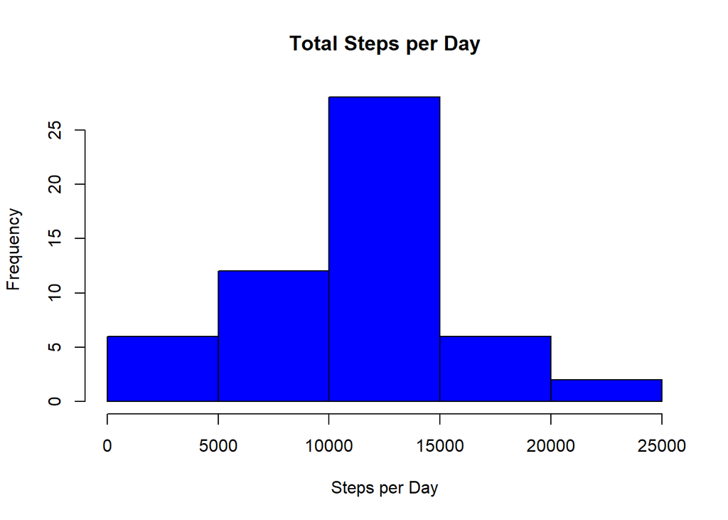

```r
hist(no_na_steps_per_day$steps, xlab = "Steps per Day", main = "Total Steps per Day", col = "blue")
```

## Calculate and report the mean and median total number of steps taken per day

```r
mean_steps <- mean(no_na_steps_per_day$steps) %>% print()
```

```
## [1] 10566.83
```

```r
median_steps <- median(no_na_steps_per_day$steps) %>% print()
```

```
## [1] 10682.5
```

## Do these values differ from the estimates from the first part of the assignment?

Calculations excluding NAs [1] 10766.19 [1] 10765

Calculations Imputing NAs [1] 10566.83 [1] 10682.5

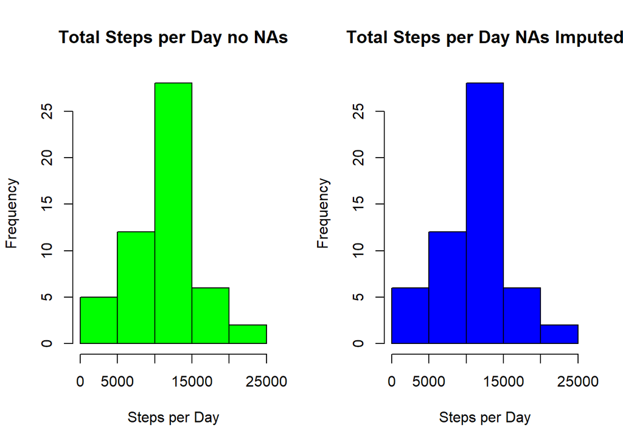

```r
par(mfrow = c(1,2))
hist(steps_per_day$steps, xlab = "Steps per Day", main = "Total Steps per Day no NAs", col = "green")
hist(no_na_steps_per_day$steps, xlab = "Steps per Day", main = "Total Steps per Day NAs Imputed", col = "blue")
```

##What is the impact of imputing missing data on the estimates of the total daily number of steps?

```r
step_diff <- sum(activity_data$steps, na.rm=T) - sum(activity_data_na_populated$steps, na.rm=T)
print(step_diff)
```

```
## [1] -1.075472
```

There is a difference of -1.075472 in the total steps between the two data-sets.

## Are there differences in activity patterns between weekdays and weekends?

1. Create a new factor variable based on Weekday vs Weekend
2. Transform dayType variable into factor

```r
DayType <- function(date) {
  day <- weekdays(date)
  if (day %in% c('Monday', 'Tuesday', 'Wednesday', 'Thursday', 'Friday'))
      return ("Weekday")
  else if (day %in% c('Saturday', 'Sunday'))
      return ("Weekend")
  else
      stop ("Invalid Date Format.")
}
activity_data_na_populated$date <- as.Date(activity_data_na_populated$date)
activity_data_na_populated$day <- sapply(activity_data_na_populated$date, FUN = DayType)
unique(activity_data_na_populated$day)
```

```
## [1] "Weekday" "Weekend"
```

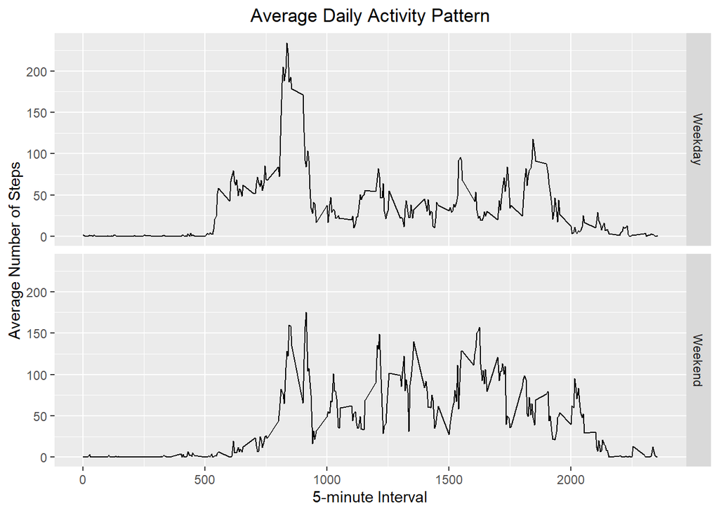

```r
meanStepsByDay <- aggregate(steps ~ interval + day, activity_data_na_populated, mean)
ggplot(data = meanStepsByDay, aes(x = interval, y = steps)) +
  geom_line() +
  facet_grid(day ~ .) +
  ggtitle("Average Daily Activity Pattern") +
  xlab("5-minute Interval") +
  ylab("Average Number of Steps") +
  theme(plot.title = element_text(hjust = 0.5))
```